# Coe Baseball Analytics Run Tables

Ryan Baranowski

8/29/2019

# Run Environment

This report studies the run environment for the American Rivers Conference (ARC), formerly the Iowa Intercollegiate Athletic Conference (IIAC). A run environment describes how many, and how frequently, runs are scored during ARC games and can be used to make informed decisions regarding in-game strategy and player development. The run environment information is created using game data from ARC games.

## Data

The data used are game boxscores from 2002-2019 and play by play data from 2017-2019 all collected through the ARC website. Game include all games played by ARC school members.

## Basics

Using game boxscore data from 2002-2019 we can look at run scoring in the ARC. Over the last five years, home teams have averaged about 5.5 runs per game while away teams are averaging closer to 6 runs per game. In any given inning, home teams average about 0.68 runs and away teams average around 0.7 runs.

Runs Per Game

| Year | Home Runs | Home R/Inning | Away Runs | Away R/Inn | Innings |
| --- | --- | --- | --- | --- | --- |
| 2002 | 6.25 | 0.87 | 6.27 | 0.86 | 7.26 |
| 2003 | 6.17 | 0.84 | 6.05 | 0.83 | 7.39 |
| 2004 | 6.43 | 0.87 | 6.56 | 0.89 | 7.44 |
| 2005 | 6.33 | 0.84 | 6.12 | 0.81 | 7.65 |
| 2006 | 6.08 | 0.79 | 5.69 | 0.74 | 7.78 |
| 2007 | 5.64 | 0.73 | 6.02 | 0.77 | 7.88 |
| 2008 | 5.61 | 0.73 | 5.98 | 0.78 | 7.76 |
| 2009 | 7.07 | 0.93 | 6.87 | 0.90 | 7.75 |
| 2010 | 7.03 | 0.90 | 6.41 | 0.82 | 7.80 |
| 2011 | 5.57 | 0.71 | 4.95 | 0.63 | 7.95 |
| 2012 | 5.57 | 0.70 | 5.05 | 0.63 | 8.04 |
| 2013 | 4.88 | 0.60 | 5.33 | 0.65 | 8.23 |
| 2014 | 5.50 | 0.67 | 5.67 | 0.69 | 8.17 |
| 2015 | 5.27 | 0.64 | 6.04 | 0.73 | 8.26 |
| 2016 | 5.90 | 0.73 | 6.10 | 0.76 | 8.18 |
| 2017 | 5.40 | 0.65 | 5.63 | 0.68 | 8.44 |
| 2018 | 5.92 | 0.72 | 5.71 | 0.69 | 8.46 |

The distribution of runs scored in a game is as follows. Most game teams score between 1 and 6 runs in a given game. Home teams are more likely to score 2+ runs, but do not have quite as many outlier, high run, games.

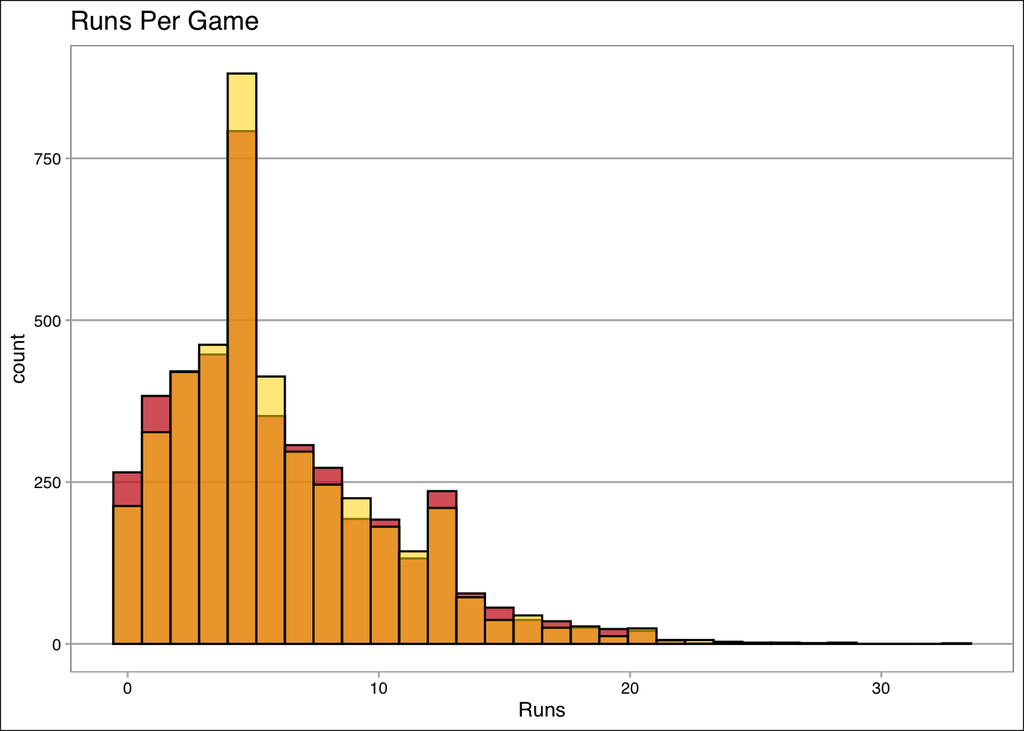

Runs Per Inning

| Year | top_1_mean | top_2_mean | top_3_mean | top_4_mean | top_5_mean | top_6_mean | top_7_mean | top_8_mean | top_9_mean | bot_1_mean | bot_2_mean | bot_3_mean | bot_4_mean | bot_5_mean | bot_6_mean | bot_7_mean | bot_8_mean | bot_9_mean | top_1_sd | top_2_sd | top_3_sd | top_4_sd | top_5_sd | top_6_sd | top_7_sd | top_8_sd | top_9_sd | bot_1_sd | bot_2_sd | … |
| --- | --- | --- | --- | --- | --- | --- | --- | --- | --- | --- | --- | --- | --- | --- | --- | --- | --- | --- | --- | --- | --- | --- | --- | --- | --- | --- | --- | --- | --- | --- |
| 2002 | 0.79 | 0.75 | 0.98 | 0.81 | 0.95 | 0.96 | 0.85 | 0.78 | 0.58 | 0.90 | 0.76 | 1.18 | 0.98 | 0.82 | 1.04 | 0.72 | 0.79 | 0.52 | 1.36 | 1.48 | 1.65 | 1.48 | 1.47 | 1.62 | 1.59 | 1.41 | 0.90 | 1.44 | 1.27 | … |
| 2003 | 0.84 | 0.70 | 0.93 | 0.81 | 0.79 | 0.75 | 0.85 | 0.97 | 1.00 | 0.91 | 0.84 | 0.96 | 0.79 | 1.05 | 0.94 | 0.70 | 0.60 | 0.78 | 1.28 | 1.14 | 1.58 | 1.42 | 1.41 | 1.26 | 1.46 | 1.61 | 1.79 | 1.53 | 1.39 | … |
| 2004 | 0.87 | 0.78 | 0.88 | 0.86 | 1.09 | 0.90 | 0.74 | 0.99 | 0.91 | 0.95 | 0.83 | 0.93 | 0.95 | 1.00 | 0.94 | 0.83 | 0.79 | 0.97 | 1.44 | 1.53 | 1.62 | 1.39 | 1.80 | 1.43 | 1.39 | 1.60 | 1.53 | 1.45 | 1.41 | … |
| 2005 | 0.93 | 0.66 | 0.73 | 0.96 | 0.73 | 0.93 | 0.72 | 0.74 | 0.70 | 0.87 | 0.74 | 0.94 | 1.01 | 1.03 | 0.87 | 0.69 | 0.85 | 0.70 | 1.41 | 1.24 | 1.38 | 1.47 | 1.36 | 1.67 | 1.30 | 1.25 | 1.24 | 1.35 | 1.33 | … |
| 2006 | 0.88 | 0.63 | 0.68 | 0.82 | 0.59 | 0.84 | 0.68 | 0.54 | 0.99 | 0.94 | 0.86 | 0.79 | 0.85 | 0.82 | 0.91 | 0.69 | 0.68 | 0.62 | 1.38 | 1.12 | 1.29 | 1.46 | 1.06 | 1.45 | 1.21 | 1.03 | 1.53 | 1.62 | 1.64 | … |
| 2007 | 0.67 | 0.65 | 0.67 | 0.72 | 0.90 | 0.81 | 0.84 | 1.00 | 0.76 | 0.82 | 0.71 | 0.82 | 0.71 | 0.85 | 0.82 | 0.69 | 0.69 | 0.47 | 1.14 | 1.21 | 1.26 | 1.34 | 1.61 | 1.48 | 1.56 | 1.51 | 1.45 | 1.41 | 1.13 | … |
| 2008 | 0.87 | 0.79 | 0.71 | 0.84 | 0.81 | 0.69 | 0.84 | 0.58 | 0.52 | 0.81 | 0.75 | 0.86 | 0.83 | 0.75 | 0.74 | 0.69 | 0.72 | 0.46 | 1.42 | 1.34 | 1.28 | 1.55 | 1.42 | 1.38 | 1.34 | 1.16 | 1.15 | 1.36 | 1.41 | … |
| 2009 | 0.87 | 0.90 | 0.75 | 0.81 | 1.00 | 0.99 | 0.91 | 0.96 | 0.73 | 0.97 | 1.00 | 0.97 | 0.91 | 1.11 | 1.06 | 0.86 | 0.82 | 0.49 | 1.42 | 1.72 | 1.27 | 1.28 | 1.66 | 1.75 | 1.48 | 1.54 | 1.24 | 1.58 | 1.71 | … |
| 2010 | 1.08 | 0.68 | 0.79 | 0.70 | 0.90 | 0.95 | 0.80 | 0.64 | 0.61 | 1.03 | 1.03 | 0.94 | 1.05 | 1.08 | 0.85 | 0.80 | 0.89 | 0.68 | 1.65 | 1.27 | 1.33 | 1.41 | 1.58 | 1.64 | 1.31 | 1.28 | 1.04 | 1.66 | 1.79 | … |
| 2011 | 0.61 | 0.44 | 0.62 | 0.56 | 0.69 | 0.81 | 0.74 | 0.39 | 0.59 | 0.92 | 0.67 | 0.81 | 0.76 | 0.71 | 0.66 | 0.73 | 0.85 | 0.47 | 1.17 | 0.97 | 1.24 | 1.14 | 1.30 | 1.46 | 1.61 | 0.83 | 1.06 | 1.61 | 1.30 | … |
| 2012 | 0.57 | 0.63 | 0.57 | 0.59 | 0.76 | 0.65 | 0.63 | 0.56 | 0.64 | 0.74 | 0.83 | 0.75 | 0.72 | 0.87 | 0.66 | 0.57 | 0.93 | 0.36 | 1.04 | 1.34 | 1.17 | 1.29 | 1.32 | 1.23 | 1.33 | 1.11 | 1.05 | 1.37 | 1.73 | … |
| 2013 | 0.71 | 0.53 | 0.72 | 0.72 | 0.70 | 0.59 | 0.52 | 0.68 | 0.64 | 0.76 | 0.48 | 0.62 | 0.58 | 0.76 | 0.71 | 0.66 | 0.56 | 0.25 | 1.26 | 1.21 | 1.30 | 1.37 | 1.23 | 1.17 | 1.04 | 1.11 | 1.18 | 1.37 | 1.03 | … |
| 2014 | 0.77 | 0.69 | 0.65 | 0.73 | 0.66 | 0.80 | 0.61 | 0.61 | 0.68 | 0.69 | 0.80 | 0.87 | 0.66 | 0.67 | 0.75 | 0.53 | 0.79 | 0.52 | 1.41 | 1.51 | 1.11 | 1.37 | 1.10 | 1.33 | 1.15 | 1.21 | 1.14 | 1.35 | 1.44 | … |
| 2015 | 0.62 | 0.58 | 0.75 | 0.81 | 0.77 | 0.90 | 0.66 | 0.85 | 0.73 | 0.77 | 0.46 | 0.72 | 0.68 | 0.66 | 0.73 | 0.69 | 0.68 | 0.59 | 1.21 | 1.31 | 1.31 | 1.38 | 1.38 | 1.52 | 1.29 | 1.58 | 1.32 | 1.36 | 0.94 | … |
| 2016 | 0.87 | 0.68 | 0.63 | 0.68 | 0.75 | 0.93 | 0.81 | 0.64 | 0.68 | 0.67 | 0.77 | 0.90 | 0.78 | 0.70 | 0.81 | 0.73 | 0.77 | 0.72 | 1.37 | 1.30 | 1.06 | 1.34 | 1.34 | 1.54 | 1.39 | 1.14 | 1.21 | 1.18 | 1.52 | … |
| 2017 | 0.64 | 0.49 | 0.68 | 0.79 | 0.66 | 0.70 | 0.67 | 0.85 | 0.58 | 0.80 | 0.59 | 0.66 | 0.62 | 0.69 | 0.68 | 0.73 | 0.72 | 0.52 | 1.31 | 1.02 | 1.32 | 1.37 | 1.25 | 1.31 | 1.22 | 1.50 | 1.09 | 1.53 | 1.22 | … |
| 2018 | 0.63 | 0.70 | 0.77 | 0.52 | 0.64 | 0.67 | 0.76 | 0.70 | 0.64 | 0.75 | 0.56 | 0.76 | 0.80 | 0.65 | 0.96 | 0.75 | 0.81 | 0.65 | 1.17 | 1.18 | 1.26 | 1.03 | 1.12 | 1.34 | 1.43 | 1.34 | 1.42 | 1.41 | 1.21 | … |

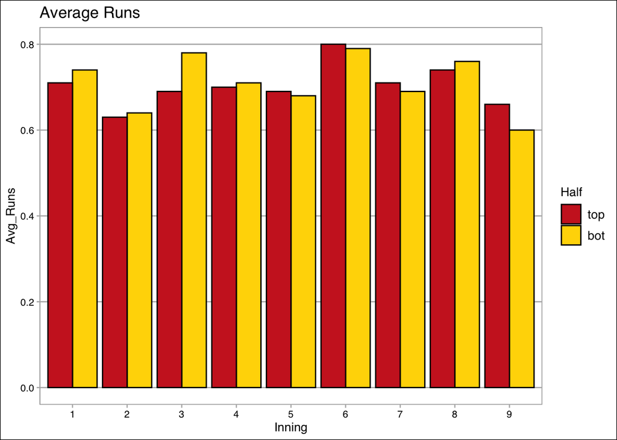

## Advanced

While looking at run scoring for games and innings is important, it lacks much of the context for what happened in each inning. To better understand how runs are scored in any given inning, and how many runs to expect in any situation, we must take a closer look at the context for which runs are scored. The context of a baseball game consists of innings, outs, and bases. Within every inning there are three outs and three bases which can be occupied during those outs. Therefore, there are 24 base/out states in an given inning. For instance, one possible state is a runner on second and third with one out. These base/out states give context for how runs are scored within an inning.

### Run Expectancy

Using play-by-play data from the 2017-2019 we can find the run expectancy for any of the 24 base/out states. On average, when a team starts an inning (base/out state of nobody on, nobody out) a team will score 0.66 runs before the inning ends. If the leadoff hitter hits a double the run expectancy jumps to 1.49 runs until the end of the inning. As the base/out state transitioned, so did the run expectancy which increased by 0.83 runs. The double was the event that triggered the state change and is worth 0.83 runs on average. It doesn’t matter if the event was a double or a single with an error that led to a runner on second with no outs, the event is worth 0.83 runs. The following is run expectancy for all 24 base/out states in the ARC.

Run Expectancy

| Base | 0 Outs | 1 Out | 2 Outs |
| --- | --- | --- | --- |
| 000 | 0.66 | 0.33 | 0.11 |
| 100 | 1.15 | 0.66 | 0.26 |
| 010 | 1.49 | 0.87 | 0.39 |
| 001 | 1.68 | 1.19 | 0.45 |
| 110 | 1.93 | 1.21 | 0.51 |
| 101 | 2.13 | 1.44 | 0.64 |
| 011 | 2.43 | 1.56 | 0.78 |
| 111 | 2.70 | 1.90 | 0.96 |

### Run Values

Using the run expectancy matrix we can find the average run value of any event (single, double, stolen base, etc.). The run values for these events can then be used to calculate a context-neutral run value of any player based on more standard accumulated stats. When evaluating the run value of an event it’s important to account for the context of the event. For instance, a sacrifice bunt is typically performed with runners on base and no out which have higher run expectancies than the start of an inning. To find the run value of an event we calculate the average number of runs scored until the end of the inning after the event and substract the starting run expectancy.

Run Value

| Event | N | Runs to End of Inning | Average Runs | Starting RE | Run Value |
| --- | --- | --- | --- | --- | --- |
| home run | 442 | 1008 | 2.28 | 0.69 | 1.59 |
| triple | 379 | 738 | 1.95 | 0.72 | 1.23 |
| double | 2417 | 3825 | 1.58 | 0.71 | 0.87 |
| single | 9443 | 12003 | 1.27 | 0.72 | 0.55 |
| error | 1647 | 2002 | 1.22 | 0.73 | 0.49 |
| hit by pitch | 1516 | 1768 | 1.17 | 0.70 | 0.47 |
| walk | 4778 | 5268 | 1.10 | 0.71 | 0.39 |
| wild pitch | 1260 | 1627 | 1.29 | 0.90 | 0.39 |
| balk | 171 | 208 | 1.22 | 0.94 | 0.28 |
| pickoff error | 88 | 106 | 1.20 | 0.92 | 0.28 |
| interference | 6 | 5 | 0.83 | 0.57 | 0.26 |
| passed ball | 401 | 432 | 1.08 | 0.87 | 0.21 |
| stolen base | 1607 | 1577 | 0.98 | 0.78 | 0.20 |
| generic out | 21292 | 6759 | 0.32 | 0.68 | -0.36 |
| fielder’s choice | 1532 | 1029 | 0.67 | 1.06 | -0.39 |
| strikeout | 8568 | 2318 | 0.27 | 0.67 | -0.40 |
| caught stealing | 481 | 97 | 0.20 | 0.75 | -0.55 |
| pickoff | 290 | 81 | 0.28 | 0.87 | -0.59 |

### Scoring Distributions

The run expectancy matrix gives the average runs expected until the end of an inning given any base/out state. However, we would also like to know the probability of scoring runs given any base out state. Back to the sacrifice bunt example, we know the sacrifice bunt lowers the run expectancy, but does it increase the probability of scoring one run? Below is the scoring distribution for all ARC team games from 2017-2019

Scoring Distribution (%)

| State | RE | 0 Runs | 1 Run | 2 Runs | 3 Runs | 4+ Runs |
| --- | --- | --- | --- | --- | --- | --- |
| 000 0 | 0.66 | 67.6 | 16.0 | 8.0 | 4.3 | 4.1 |
| 000 1 | 0.33 | 82.0 | 10.0 | 4.3 | 2.1 | 1.5 |
| 000 2 | 0.11 | 93.0 | 4.4 | 1.6 | 0.6 | 0.4 |
| 001 0 | 1.68 | 9.9 | 50.4 | 18.4 | 11.4 | 9.9 |
| 001 1 | 1.19 | 25.3 | 52.0 | 13.0 | 3.8 | 5.9 |
| 001 2 | 0.45 | 65.8 | 26.2 | 5.7 | 1.5 | 0.7 |
| 010 0 | 1.49 | 29.3 | 34.7 | 16.2 | 8.6 | 11.1 |
| 010 1 | 0.87 | 51.3 | 27.9 | 11.3 | 5.2 | 4.3 |
| 010 2 | 0.39 | 73.8 | 17.9 | 5.5 | 1.8 | 1.0 |
| 011 0 | 2.43 | 10.3 | 20.4 | 32.8 | 15.5 | 21.0 |
| 011 1 | 1.56 | 26.4 | 28.3 | 26.1 | 10.0 | 9.2 |
| 011 2 | 0.78 | 64.7 | 9.7 | 16.5 | 4.9 | 4.2 |
| 100 0 | 1.15 | 48.6 | 21.7 | 13.9 | 7.6 | 8.2 |
| 100 1 | 0.66 | 67.1 | 15.3 | 9.2 | 4.7 | 3.7 |
| 100 2 | 0.26 | 84.7 | 8.7 | 3.9 | 1.8 | 0.9 |
| 101 0 | 2.13 | 9.6 | 36.3 | 22.5 | 13.6 | 18.0 |
| 101 1 | 1.44 | 26.6 | 37.5 | 17.6 | 9.4 | 8.8 |
| 101 2 | 0.64 | 63.2 | 21.5 | 9.1 | 3.7 | 2.5 |
| 110 0 | 1.93 | 27.0 | 23.7 | 20.0 | 11.8 | 17.5 |
| 110 1 | 1.21 | 48.6 | 17.6 | 15.4 | 9.6 | 8.9 |
| 110 2 | 0.51 | 74.1 | 11.4 | 7.4 | 4.5 | 2.6 |
| 111 0 | 2.70 | 12.0 | 20.9 | 19.4 | 15.2 | 32.5 |
| 111 1 | 1.90 | 26.2 | 25.4 | 18.1 | 13.0 | 17.3 |
| 111 2 | 0.96 | 59.2 | 13.3 | 12.6 | 7.4 | 7.5 |

With a runner on first and nobody out, an average team can expect to score zero runs 48.6% of the time and has a 21.7% chance of scoring exactly one run. A successful sacrifice bunt moving the runner to second with one out increases the probability of scoring zero runs to 51.3%, or a 2.7% increase and only increases the probability of scoring 1 run by 6.2% (from 21.7% to 27.9%), but decreases the probability of scoring 2 or more runs. A successful sacrifice bunt does slightly increase the chances of scoring one run, but it also increases the chance of scoring no runs because one of three outs was used. What if the sacrifice bunt is unsuccesful transitioning to a runner on first one out state? An unsuccessful bunt is very costly increasing the probability of scoring no runs from 48.6% to 67.1%, increasing the chance of not scoring by 18.5%!

### Win Probability

We can expand our analysis to study how run differentials effect win probabilities. For any given inning, out, run differential state we find the probability that a team wins the game.

Win Probability (%)

| Inning | Outs | Half | Run Differential -4+ | Run Differential -3 | Run Differential -2 | Run Differential -1 | Run Differential 0 | Run Differential 1 | Run Differential 2 | Run Differential 3 | Run Differential 4+ |
| --- | --- | --- | --- | --- | --- | --- | --- | --- | --- | --- | --- |
| 1 | 0 | top | 0.20 | 0.25 | 0.18 | 0.19 | 0.47 | NA | NA | NA | NA |
| 1 | 1 | top | 0.00 | 0.25 | 0.18 | 0.33 | 0.49 | NA | NA | NA | NA |
| 1 | 2 | top | 0.16 | 0.17 | 0.38 | 0.36 | 0.51 | NA | NA | NA | NA |
| 1 | 0 | bottom | 0.16 | 0.32 | 0.41 | 0.37 | 0.53 | 0.76 | 0.80 | 0.83 | 0.80 |
| 1 | 1 | bottom | 0.13 | 0.24 | 0.40 | 0.37 | 0.51 | 0.66 | 0.69 | 0.94 | 0.92 |
| 1 | 2 | bottom | 0.09 | 0.05 | 0.33 | 0.32 | 0.49 | 0.65 | 0.66 | 0.92 | 1.00 |
| 2 | 0 | top | 0.09 | 0.05 | 0.25 | 0.32 | 0.46 | 0.63 | 0.50 | 0.89 | 0.96 |
| 2 | 1 | top | 0.06 | 0.12 | 0.26 | 0.32 | 0.45 | 0.63 | 0.55 | 0.94 | 0.96 |
| 2 | 2 | top | 0.07 | 0.19 | 0.29 | 0.38 | 0.49 | 0.62 | 0.58 | 0.93 | 0.95 |
| 2 | 0 | bottom | 0.06 | 0.29 | 0.33 | 0.39 | 0.50 | 0.67 | 0.60 | 0.96 | 0.96 |
| 2 | 1 | bottom | 0.08 | 0.27 | 0.31 | 0.41 | 0.51 | 0.63 | 0.65 | 0.89 | 0.95 |
| 2 | 2 | bottom | 0.10 | 0.22 | 0.31 | 0.37 | 0.47 | 0.60 | 0.64 | 0.74 | 0.91 |
| 3 | 0 | top | 0.02 | 0.16 | 0.31 | 0.33 | 0.46 | 0.58 | 0.60 | 0.73 | 0.91 |
| 3 | 1 | top | 0.02 | 0.14 | 0.29 | 0.33 | 0.47 | 0.58 | 0.62 | 0.79 | 0.92 |
| 3 | 2 | top | 0.04 | 0.18 | 0.36 | 0.40 | 0.45 | 0.58 | 0.76 | 0.77 | 0.92 |
| 3 | 0 | bottom | 0.05 | 0.16 | 0.37 | 0.45 | 0.49 | 0.62 | 0.75 | 0.81 | 0.96 |
| 3 | 1 | bottom | 0.04 | 0.16 | 0.37 | 0.43 | 0.49 | 0.65 | 0.75 | 0.84 | 0.94 |
| 3 | 2 | bottom | 0.02 | 0.09 | 0.30 | 0.39 | 0.43 | 0.64 | 0.67 | 0.83 | 0.91 |
| 4 | 0 | top | 0.04 | 0.12 | 0.26 | 0.31 | 0.39 | 0.61 | 0.69 | 0.81 | 0.92 |
| 4 | 1 | top | 0.04 | 0.16 | 0.22 | 0.30 | 0.41 | 0.61 | 0.71 | 0.83 | 0.92 |
| 4 | 2 | top | 0.03 | 0.19 | 0.23 | 0.33 | 0.44 | 0.64 | 0.77 | 0.83 | 0.91 |
| 4 | 0 | bottom | 0.05 | 0.21 | 0.22 | 0.36 | 0.50 | 0.64 | 0.79 | 0.87 | 0.92 |
| 4 | 1 | bottom | 0.05 | 0.21 | 0.18 | 0.38 | 0.53 | 0.60 | 0.78 | 0.80 | 0.92 |
| 4 | 2 | bottom | 0.06 | 0.23 | 0.18 | 0.30 | 0.46 | 0.60 | 0.71 | 0.81 | 0.92 |
| 5 | 0 | top | 0.03 | 0.20 | 0.14 | 0.29 | 0.41 | 0.58 | 0.66 | 0.80 | 0.93 |
| 5 | 1 | top | 0.05 | 0.19 | 0.19 | 0.30 | 0.45 | 0.59 | 0.69 | 0.77 | 0.92 |
| 5 | 2 | top | 0.06 | 0.23 | 0.16 | 0.35 | 0.45 | 0.60 | 0.70 | 0.85 | 0.95 |
| 5 | 0 | bottom | 0.06 | 0.25 | 0.20 | 0.38 | 0.49 | 0.60 | 0.82 | 0.85 | 0.96 |
| 5 | 1 | bottom | 0.06 | 0.21 | 0.18 | 0.38 | 0.52 | 0.59 | 0.80 | 0.86 | 0.96 |
| 5 | 2 | bottom | 0.05 | 0.21 | 0.15 | 0.27 | 0.50 | 0.58 | 0.72 | 0.83 | 0.95 |
| 6 | 0 | top | 0.03 | 0.15 | 0.12 | 0.23 | 0.43 | 0.56 | 0.67 | 0.80 | 0.96 |
| 6 | 1 | top | 0.02 | 0.15 | 0.12 | 0.24 | 0.45 | 0.53 | 0.71 | 0.83 | 0.96 |
| 6 | 2 | top | 0.04 | 0.13 | 0.16 | 0.25 | 0.44 | 0.55 | 0.76 | 0.85 | 0.98 |
| 6 | 0 | bottom | 0.03 | 0.19 | 0.17 | 0.28 | 0.47 | 0.61 | 0.86 | 0.87 | 0.99 |
| 6 | 1 | bottom | 0.02 | 0.16 | 0.21 | 0.24 | 0.49 | 0.65 | 0.82 | 0.82 | 0.98 |
| 6 | 2 | bottom | 0.02 | 0.11 | 0.13 | 0.19 | 0.45 | 0.55 | 0.82 | 0.87 | 0.98 |
| 7 | 0 | top | 0.02 | 0.06 | 0.09 | 0.10 | 0.34 | 0.54 | 0.76 | 0.81 | 0.97 |
| 7 | 1 | top | 0.02 | 0.06 | 0.08 | 0.11 | 0.32 | 0.55 | 0.81 | 0.84 | 0.98 |
| 7 | 2 | top | 0.03 | 0.07 | 0.09 | 0.14 | 0.31 | 0.64 | 0.77 | 0.91 | 0.99 |
| 7 | 0 | bottom | 0.03 | 0.08 | 0.13 | 0.16 | 0.34 | 0.68 | 0.85 | 0.95 | 0.98 |
| 7 | 1 | bottom | 0.02 | 0.06 | 0.15 | 0.19 | 0.34 | 0.70 | 0.86 | 0.96 | 0.98 |
| 7 | 2 | bottom | 0.01 | 0.00 | 0.08 | 0.10 | 0.24 | 0.62 | 0.82 | 0.95 | 0.99 |
| 8 | 0 | top | 0.01 | 0.03 | 0.08 | 0.12 | 0.19 | 0.59 | 0.70 | 0.88 | 0.98 |
| 8 | 1 | top | 0.01 | 0.02 | 0.07 | 0.11 | 0.20 | 0.58 | 0.84 | 0.97 | 1.00 |
| 8 | 2 | top | 0.01 | 0.03 | 0.08 | 0.09 | 0.24 | 0.64 | 0.85 | 1.00 | 1.00 |
| 8 | 0 | bottom | 0.01 | 0.05 | 0.08 | 0.16 | 0.25 | 0.78 | 0.94 | 1.00 | 1.00 |
| 8 | 1 | bottom | 0.01 | 0.08 | 0.06 | 0.07 | 0.25 | 0.75 | 0.93 | 1.00 | 1.00 |
| 8 | 2 | bottom | 0.00 | 0.00 | 0.12 | 0.07 | 0.23 | 0.80 | 0.92 | 1.00 | 1.00 |
| 9 | 0 | top | 0.00 | 0.00 | 0.00 | 0.00 | 0.02 | 0.75 | 0.84 | 1.00 | 1.00 |
| 9 | 1 | top | 0.00 | 0.00 | 0.00 | 0.00 | 0.02 | 0.89 | 0.91 | 1.00 | 1.00 |
| 9 | 2 | top | 0.00 | 0.00 | 0.00 | 0.00 | 0.02 | 0.92 | 0.97 | 1.00 | 1.00 |
| 9 | 0 | bottom | 0.00 | 0.00 | 0.00 | 0.00 | 0.02 | 0.50 | 1.00 | NA | 1.00 |
| 9 | 1 | bottom | 0.00 | 0.00 | 0.00 | 0.00 | 0.02 | 1.00 | 1.00 | NA | 1.00 |
| 9 | 2 | bottom | 0.00 | 0.00 | 0.00 | 0.00 | 0.02 | NA | NA | 1.00 | 1.00 |
| 10 | 0 | top | NA | 0.00 | NA | 0.00 | 0.00 | NA | NA | NA | NA |
| 10 | 1 | top | 0.00 | 0.00 | 0.00 | NA | 0.00 | NA | NA | NA | NA |
| 10 | 2 | top | NA | NA | 0.00 | 0.00 | 0.00 | NA | NA | NA | NA |
| 10 | 0 | bottom | 0.00 | NA | 0.00 | 0.00 | 0.00 | NA | NA | NA | NA |
| 10 | 1 | bottom | NA | NA | 0.00 | 0.00 | 0.00 | NA | NA | NA | NA |
| 10 | 2 | bottom | NA | NA | 0.00 | 0.00 | 0.00 | NA | NA | NA | NA |
| 11 | 0 | top | NA | NA | NA | 0.00 | 0.00 | NA | NA | NA | NA |
| 11 | 1 | top | 0.00 | NA | 0.00 | 0.00 | 0.00 | NA | NA | NA | NA |
| 11 | 2 | top | 0.00 | NA | 0.00 | 0.00 | 0.00 | NA | NA | NA | NA |
| 11 | 0 | bottom | 0.00 | NA | 0.00 | 0.00 | 0.00 | NA | NA | NA | NA |
| 11 | 1 | bottom | 0.00 | NA | 0.00 | 0.00 | 0.00 | NA | NA | NA | NA |
| 11 | 2 | bottom | 0.00 | NA | 0.00 | NA | 0.00 | NA | NA | NA | NA |
| 12 | 0 | top | NA | NA | NA | NA | 0.00 | NA | NA | NA | NA |
| 12 | 1 | top | NA | NA | NA | 0.00 | 0.00 | NA | NA | NA | NA |
| 12 | 2 | top | NA | NA | NA | 0.00 | NA | NA | NA | NA | NA |
| 12 | 0 | bottom | NA | NA | 0.00 | 0.00 | 0.00 | NA | NA | NA | NA |
| 12 | 1 | bottom | NA | NA | 0.00 | 0.00 | NA | NA | NA | NA | NA |
| 12 | 2 | bottom | NA | NA | 0.00 | 0.00 | 0.00 | NA | NA | NA | NA |
| 13 | 0 | top | NA | NA | NA | 0.00 | 0.00 | NA | NA | NA | NA |
| 13 | 1 | top | NA | NA | 0.00 | NA | NA | NA | NA | NA | NA |
| 13 | 2 | top | NA | NA | 0.00 | NA | NA | NA | NA | NA | NA |
| 13 | 0 | bottom | NA | NA | 0.00 | NA | NA | NA | NA | NA | NA |
| 13 | 1 | bottom | NA | NA | 0.00 | NA | NA | NA | NA | NA | NA |
| 13 | 2 | bottom | NA | NA | 0.00 | NA | NA | NA | NA | NA | NA |

All probabilities are for the home team winning the game. If the home team gives up a first inning run before making an out, the win probability drops from 47% to 19% or a 28% decline. This chart, combined with the other run scoring information, can be used to make in-game decisions that help increase run expectancy and ultimately win probability.